# Applications in Plant Sciences

[Applications in Plant Sciences](https://bsapubs.onlinelibrary.wiley.com/journal/21680450)

[Early View](https://bsapubs.onlinelibrary.wiley.com/toc/21680450/0/0) e11521

[figure not shown]

PROTOCOL NOTE

Open Access

# Optimizing efficient PCR-amplifiable DNA extraction from herbarium specimens

## This article relates to:

[Fred E. Gouker](https://bsapubs.onlinelibrary.wiley.com/authored-by/ContribAuthorRaw/Gouker/Fred+E.),

[Yonghong Guo](https://bsapubs.onlinelibrary.wiley.com/authored-by/ContribAuthorRaw/Guo/Yonghong),

[Harlan T. Svoboda](https://bsapubs.onlinelibrary.wiley.com/authored-by/ContribAuthorRaw/Svoboda/Harlan+T.),

[Margaret R. Pooler](https://bsapubs.onlinelibrary.wiley.com/authored-by/ContribAuthorRaw/Pooler/Margaret+R.),

First published: 21 May 2023

https://doi.org/10.1002/aps3.11521

This article is part of the special issue “Emerging Methods in Botanical DNA/RNA Extraction.”

## Abstract

### Premise

The objective of this study was to optimize an existing DNA extraction protocol for recalcitrant plant taxa to obtain high-quality DNA from preserved herbarium tissue suitable for downstream PCR applications.

### Methods and Results

Leaf tissue from 30 diverse plant species was obtained from the U.S. National Arboretum Herbarium. Our previous DNA extraction protocol (Gouker et al., 2020, *Applications in Plant Sciences* 8: e11403) was improved by use of 10X Tris-EDTA buffer, addition of polyvinylpolypyrrolidone, and omission of sample heating during homogenization, and resulted in total DNA yields ranging from 60–2460 ng. Optimized PCR amplification using universal plant primers for the ITS-p3/u4 region and the P6 loop of the *trnL* (UAA) chloroplast intron was successful for most specimens.

### Conclusions

This protocol, which is simple, fast, and uses standard laboratory-grade chemicals, yields DNA from herbarium specimens that is comparable in quality to that from commercially available kits, and is of sufficient quality and quantity for other applications.

Herbarium specimens are becoming increasingly recognized as a vital resource of genetic information to help answer questions related to taxonomic identity, evolutionary relationships, genetic diversity, and many other aspects across the biological sciences (Bebber et al., 2010; Davis et al., 2015; Hart et al., 2016; Souza and Hawkins, 2017). Many recently developed molecular methods and digitization tools have also greatly contributed to the utilization of herbaria. To date, there are more than 3500 active herbaria worldwide serving as primary sources of plant data, documenting spatial and temporal changes in plant diversity (Bieker et al., 2022; Thiers, 2022). Preserved collections also provide the opportunity to study taxa from wide geographic distributions, undescribed or even extinct species, as well as samples from remote locations where obtaining in situ samples may be cost- or time-prohibitive, allowing the opportunity for improved phylogenetic studies (Zuntini et al., 2013; Bieker and Martin, 2018). Additionally, genetic data from herbarium specimens can be used in conservation efforts for plant species categorized as threatened or endangered when sampling of these species may not be permitted by the governing body that legislates or manages plant protection and reintroduction (Muniz et al., 2019).

The age of a herbarium sample can affect the ability to extract a large amount of high-quality DNA due to degradation of the specimen, plant chemistry, structural characteristics, and/or method of collection and preservation (Kates et al., 2021; Marinček et al., 2022). Efforts to extract amplifiable DNA from herbarium sources can be further hindered by degradation of the DNA into small fragments. Because of these challenges, considerable effort has been spent optimizing DNA extraction protocols. Ideal extraction methods should optimize DNA yield and quality, eliminate contamination, minimize degradation and inhibitors, and reduce costs and processing times. Subsequent downstream applications for the DNA such as PCR amplification should also be considered. Although several methods have been developed to address these challenges (Lister et al., 2008; Särkinen et al., 2012; Záveská Drábková, 2021; Carey et al., 2023; Johnson et al., 2023), many protocols are complicated or rely on expensive commercial kits or require modification of frequently used techniques. These commonly used methods include modified cetyltrimethylammonium bromide (CTAB) protocols (Doyle and Doyle, 1987), which use phenol, and the DNeasy Plant Mini Kit (Qiagen, Germantown, Maryland, USA), which uses silica-membrane spin columns.

A previous study using acetone to extract DNA from herbarium and freshly collected plant samples (Gouker et al., 2020) demonstrated that sufficient quality and quantity of DNA could be extracted using this simple and cost-effective method. In this study, we improved this method to extract DNA from herbarium specimens of varying ages across 30 diverse families of woody and herbaceous plants and determined optimal PCR conditions to amplify short and long DNA fragments for use in downstream applications. This updated method lends four improvements: reduction of total procedural time by at least two hours; reduction of the amount of tissue sample used; removal of a lengthy heated incubation step; and use of polyvinylpolypyrrolidone (PVPP) to remove phenolic compounds from the DNA extracts. Because polyphenols are typically found in woody and mature plant parts, they can covalently bind and co-precipitate with nucleic acids. Removing polyphenolic contamination helps prevent the oxidation and subsequent browning of the DNA samples, which was often observed when PVPP was not used. This study also compared our improved extraction method with two commonly used DNA extraction protocols for plant specimens—using CTAB buffer and the DNeasy kit—and evaluated relative performance of extraction methods. We also optimized amplification efficiency with different *Taq* DNA polymerases using a universal nuclear and plastid molecular marker.

## METHODS AND RESULTS

### Plant material

Preserved specimens of 30 diverse plant species were selected from the U.S. National Arboretum Herbarium in Washington, D.C., USA, representing pteridophyte, gymnosperm, and angiosperm species, including herbaceous and woody taxa (Appendix 1). These specimens ranged in age from nine to 187 years old. For each species, a “new” herbarium specimen (i.e., one collected after 1960) and an “old” specimen (i.e., pre-1960) were sampled. For comparison, we also collected fresh tissue from nine living accessions growing on the grounds of the U.S. National Arboretum in Washington, D.C., USA.

### DNA amplification

We used two sets of universal plant PCR primers to test DNA quality, as measured by amplification efficiency using PCR assays. Primers were the nuclear ITS-p3/u4 (5′-YGACTCTCGGCAACGGATA-3′/5′-RGTTTCTTTTCCTCCGCTTA-3′; 445–581 bp product; Cheng et al., 2016) and the short P6 loop of the *trnL* (UAA) chloroplast intron (5′-GGGCAATCCTGAGCCAA-3′/5′-CCATTGAGTCTCTGCACCTATC-3′; 10–143 bp product; Taberlet et al., 2007). Primers were chosen based on these predicted amplicon sizes to maximize amplification success even from the often-fragmented DNA of herbarium samples (Särkinen et al., 2012; Shepherd, 2017). For each PCR reaction, a final volume of 10 μL was used, which contained 0.5 μL of each 10-μM forward and reverse primer, 2.0 μL of nuclease-free water, 1 ng of template DNA, and 1 unit of DNA polymerase. We tested four different DNA polymerases with the following reaction conditions using gradient annealing temperatures for each: Phusion High-Fidelity (Thermo Fisher Scientific), One*Taq* (New England BioLabs, Ipswich, Massachusetts, USA), Platinum II *Taq* Hot-Start (Thermo Fisher Scientific), and Mango*Taq* (Meridian Bioscience, Memphis, Tennessee, USA), with 5 min of preheating at 95°C, followed by 35 cycles of 10 s of denaturation at 95°C, 10 s of annealing from 52°C to 60°C in 2°C increments, and 10 s of extension at 72°C. A blank control was used for each PCR primer. Five microliters of each PCR product were evaluated on a 1.5% agarose gel stained with GelRed (Biotium, Fremont, California, USA) to verify amplification by visual presence of gel bands; all visible bands of the expected size were recorded as positive amplicons (Table 1). To confirm amplification of the target region and test for contamination, we sequenced amplicons from the ITS-p3/u4 PCR product from old and new *Buxus sempervirens* L. and *Acer rubrum* L. herbarium samples that had been amplified using the optimized PCR conditions with Invitrogen Platinum II *Taq* Hot-Start DNA Polymerase (Thermo Fisher Scientific) at an annealing temperature of 54°C. For these samples, PCR products were purified using exonuclease I and shrimp alkaline phosphatase (Exo/SAP) and were Sanger sequenced with forward and reverse primers by Psomagen (Rockville, Maryland, USA). Sequences were trimmed and aligned using the Sequencher software (Gene Codes, Ann Arbor, Michigan, USA) and confirmed to be the expected ITS-p3/u4 region (data not shown).

Table 1. DNA concentrations and quality as measured by PCR amplification of herbarium and fresh samples using our improved acetone method vs. the CTAB and Qiagen DNeasy Plant Mini Kit protocols, and PCR success of two universal plant primer pairs.

| Taxon | Habit | Conditiona/Yearb | Acetone DNA Concentration (ng/μL) | Acetone DNA A<sub>260</sub>/A<sub>280</sub> ratio | Acetone PCR amplification<sup>c</sup> ITS-p3/u4 | Acetone PCR amplification<sup>c</sup> P6 loop | CTAB DNA Concentration (ng/μL) | CTAB DNA A<sub>260</sub>/A<sub>280</sub> ratio | CTAB PCR amplification<sup>c</sup> ITS-p3/u4 | CTAB PCR amplification<sup>c</sup> P6 loop | Qiagen DNeasy Plant Mini Ki DNA Concentration (ng/μL) | Qiagen DNeasy Plant Mini Ki DNA A<sub>260</sub>/A<sub>280</sub> ratio | Qiagen DNeasy Plant Mini Ki PCR amplification<sup>c</sup> ITS-p3/u4 | Qiagen DNeasy Plant Mini Ki PCR amplification<sup>c</sup> P6 loop |
| --- | --- | --- | --- | --- | --- | --- | --- | --- | --- | --- | --- | --- | --- | --- |
| *Acer rubrum* | Woody | Old (1926) | 211.4 | 1.16 | No | ✓ | 271.57 | 2.06 | ✓ | ✓ | 20.3 | 0.93 | ✓ | ✓ |
|  |  | New (2007) | 248.1 | 1.57 | ✓ | ✓ | 134.81 | 1.99 | ✓ | ✓ | 13.1 | 1.8 | ✓ | ✓ |
|  |  | Fresh | 182.7 | 1.43 | ✓ | ✓ | — | — | — | — | 10.6 | 1.63 | ✓ | ✓ |
| *Buxus sempervirens* | Woody | Old (1906) | 293 | 1.3 | ✓ | ✓ | 71.25 | 1.88 | ✓ | ✓ | 6.3 | 1.75 | ✓ | ✓ |
|  |  | New (1984) | 367.2 | 1.3 | No | ✓ | 26.39 | 1.68 | ✓ | ✓ | 1.2 | 1.33 | ✓ | ✓ |
|  |  | Fresh | 242.3 | 1.41 | ✓ | ✓ | — | — | — | — | 8.1 | 1.76 | ✓ | ✓ |
| *Celosia argentea* | Herbaceous | Old (1917) | 1628.6 | 1.35 | ✓ | ✓ | 108.58 | 1.82 | ✓ | ✓ | 6.7 | 1.53 | ✓ | ✓ |
|  |  | New (1994) | 247.1 | 1.38 | ✓ | ✓ | 136.92 | 1.89 | ✓ | ✓ | 4 | 1.73 | ✓ | ✓ |
|  |  | Fresh | 201 | 1.51 | ✓ | ✓ | — | — | — | — | 7 | 1.54 | ✓ | ✓ |
| *Cephalanthus occidentalis* | Woody | Old (1894) | 372.7 | 1.33 | ✓ | ✓ | 275.27 | 1.91 | ✓ | ✓ | 8.02 | 1.1 | ✓ | ✓ |
|  |  | New (2002) | 402.2 | 1.35 | ✓ | ✓ | 76.39 | 1.86 | ✓ | ✓ | 23.88 | 1.32 | ✓ | ✓ |
| *Chrysanthemum indicum* | Herbaceous | Old (1924) | 522.4 | 1.3 | ✓ | ✓ | 32.07 | 1.79 | ✓ | ✓ | 5.66 | 1.17 | ✓ | ✓ |
|  |  | New (1984) | 170.7 | 1.21 | No | ✓ | 62.4 | 1.68 | ✓ | ✓ | 6.36 | 1.41 | ✓ | ✓ |
| *Cycas revoluta* | Woody | Old (1913) | 45.3 | 1.3 | No | ✓ | 78.74 | 1.99 | ✓ | ✓ | 15.34 | 1.82 | ✓ | ✓ |
|  |  | New (1981) | 93.8 | 1.29 | ✓ | ✓ | 13.24 | 1.99 | ✓ | ✓ | 1.72 | 2.79 | No | ✓ |
| *Dioscorea japonica* | Herbaceous | Old (1915) | 176 | 1.3 | No | ✓ | 27.39 | 1.87 | No | ✓ | 1.9 | 1.08 | No | ✓ |
|  |  | New (1986) | 181.1 | 1.33 | No | ✓ | 6.64 | 1.49 | ✓ | ✓ | 3.95 | 1.63 | ✓ | ✓ |
| *Dryopteris marginalis* | Herbaceous | Old (1912) | 974.5 | 1.2 | ✓ | ✓ | 59.66 | 1.86 | ✓ | ✓ | 8.33 | 1.24 | ✓ | ✓ |
|  |  | New (2001) | 445.9 | 1.19 | No | No | 30.41 | 1.89 | ✓ | ✓ | 21.24 | 1.64 | ✓ | ✓ |
| *Goodyera pubescens* | Herbaceous | Old (1884) | 1186 | 1.35 | No | ✓ | 24.55 | 1.76 | ✓ | ✓ | 10.58 | 1.42 | ✓ | ✓ |
|  |  | New (1966) | 1638.2 | 1.33 | No | ✓ | 8.26 | 1.29 | No | ✓ | 3.96 | 1.44 | ✓ | ✓ |
| *Hamamelis virginiana* | Woody | Old (1835) | 512.8 | 1.34 | No | ✓ | 80.89 | 1.93 | ✓ | ✓ | 2.5 | 1.08 | ✓ | ✓ |
|  |  | New (1997) | 348.6 | 1.41 | No | ✓ | 100.65 | 2.02 | ✓ | ✓ | 1.5 | 1.13 | ✓ | ✓ |
|  |  | Fresh | 358.9 | 1.18 | ✓ | ✓ | — | — | — | — | 0.8 | 0.44 | ✓ | ✓ |
| *Ilex opaca* | Woody | Old (1898) | 136.2 | 1.16 | No | No | 89.33 | 1.96 | No | ✓ | 4.2 | 1.31 | ✓ | ✓ |
|  |  | New (1981) | 855.8 | 1.33 | No | ✓ | 79.51 | 1.96 | ✓ | ✓ | 4.1 | 1.35 | ✓ | ✓ |
|  |  | Fresh | 148 | 1.41 | ✓ | ✓ | — | — | — | — | 3.3 | 1.25 | ✓ | ✓ |
| *Juniperus occidentalis* | Woody | Old (1882) | 565.9 | 1.28 | ✓ | ✓ | 721.4 | 1.9 | ✓ | ✓ | 27.96 | 1.3 | No | No |
|  |  | New (1971) | 23.6 | 1.22 | ✓ | ✓ | 380.53 | 1.91 | ✓ | ✓ | 98.52 | 1.82 | ✓ | ✓ |
| *Lagerstroemia indica* | Woody | Old (1921) | 210 | 1.15 | ✓ | ✓ | 190.74 | 1.38 | ✓ | ✓ | 35.71 | 1.14 | ✓ | ✓ |
|  |  | New (1987) | 900.9 | 1.33 | No | No | 305.09 | 1.44 | ✓ | ✓ | 52.76 | 1.12 | ✓ | ✓ |
| *Lilium superbum* | Herbaceous | Old (1880) | 920.9 | 1.41 | No | No | 18.98 | 1.8 | ✓ | ✓ | 7.16 | 1.45 | ✓ | ✓ |
|  |  | New (1979) | 241.3 | 1.33 | No | ✓ | 283.15 | 1.97 | ✓ | ✓ | 28.98 | 1.78 | ✓ | ✓ |
| *Magnolia virginiana* | Woody | Old (1924) | 545.2 | 1.34 | ✓ | ✓ | 63.76 | 1.92 | ✓ | ✓ | 2.4 | 2.24 | ✓ | ✓ |
|  |  | New (2001) | 294.6 | 1.37 | ✓ | ✓ | 76.38 | 2.01 | ✓ | ✓ | 10.4 | 1.8 | ✓ | ✓ |
|  |  | Fresh | 342.5 | 1.33 | ✓ | ✓ | — | — | — | — | 10.3 | 1.87 | ✓ | ✓ |
| *Nymphaea odorata* | Herbaceous | Old (1877) | 793.3 | 1.29 | ✓ | ✓ | 204.22 | 2.03 | No | ✓ | 6.4 | 0.64 | ✓ | ✓ |
|  |  | New (1999) | 545.9 | 1.21 | No | ✓ | 2.89 | 1.65 | ✓ | ✓ | 26.47 | 1.2 | ✓ | ✓ |
| *Osmorhiza longistylis* | Herbaceous | Old (1924) | 192.8 | 1.3 | ✓ | ✓ | 4.6 | 2 | No | ✓ | 11.58 | 1.44 | No | ✓ |
|  |  | New (1997) | 280.2 | 1.36 | No | ✓ | 59.85 | 1.96 | ✓ | ✓ | 25.43 | 1.75 | ✓ | ✓ |
| *Panicum virgatum* | Herbaceous | Old (1884) | 168.2 | 1.39 | ✓ | ✓ | 137.03 | 2.07 | ✓ | ✓ | 3 | 1.31 | ✓ | ✓ |
|  |  | New (2008) | 117.1 | 1.42 | ✓ | ✓ | 241.66 | 2.02 | ✓ | ✓ | 9.1 | 1.87 | ✓ | ✓ |
|  |  | Fresh | 199 | 1.58 | ✓ | ✓ | — | — | — | — | 11.5 | 1.86 | ✓ | ✓ |
| *Papaver somniferum* | Herbaceous | Old (1920) | 112.8 | 1.39 | No | ✓ | 70.95 | 1.86 | No | ✓ | 5.53 | 1.22 | ✓ | ✓ |
|  |  | New (1972) | 226.7 | 1.37 | ✓ | ✓ | 128.44 | 2.09 | ✓ | ✓ | 25.42 | 1.81 | ✓ | ✓ |
| *Pinus pinceana* | Woody | Old (1939) | 167 | 1.4 | ✓ | ✓ | 224.13 | 1.94 | ✓ | ✓ | 35.34 | 1.81 | ✓ | ✓ |
|  |  | New (1994) | 108.6 | 1.34 | ✓ | ✓ | 420.05 | 1.99 | ✓ | ✓ | 24.74 | 1.81 | ✓ | ✓ |
| *Piper barbicuspe* | Herbaceous | Old (1935) | 200.2 | 1.25 | ✓ | ✓ | 89.98 | 1.69 | ✓ | ✓ | 3.49 | 0.9 | No | ✓ |
|  |  | New (1973) | 14.1 | 1.17 | No | ✓ | 92.81 | 1.86 | ✓ | ✓ | 11.17 | 1.42 | ✓ | ✓ |
| *Prunus angustifolia* | Woody | Old (1910) | 606.2 | 1.35 | ✓ | ✓ | 344.92 | 1.88 | ✓ | ✓ | 12.87 | 1.11 | ✓ | ✓ |
|  |  | New (1983) | 403.1 | 1.07 | No | ✓ | 162.82 | 1.85 | ✓ | ✓ | 22.33 | 0.99 | ✓ | ✓ |
| *Quercus alba* | Woody | Old (1893) | 502.1 | 1.21 | ✓ | No | 113.26 | 1.96 | ✓ | ✓ | 20.1 | 1.18 | ✓ | ✓ |
|  |  | New (2013) | 13.7 | 1.04 | ✓ | ✓ | 2.29 | 1.26 | ✓ | ✓ | 16.9 | 1.65 | ✓ | ✓ |
|  |  | Fresh | 49.2 | 1.37 | ✓ | ✓ | — | — | — | — | 8.9 | 1.53 | — | — |
| *Rhododendron calendulaceum* | Woody | Old (1916) | 396.5 | 1.28 | ✓ | ✓ | 57.2 | 2.06 | ✓ | ✓ | 8.8 | 1.52 | ✓ | ✓ |
|  |  | New (1988) | 374.1 | 1.29 | ✓ | ✓ | 232.58 | 2.03 | ✓ | ✓ | 21.69 | 1.63 | ✓ | ✓ |
| *Salix caroliniana* | Woody | Old (1902) | 256.6 | 1.42 | ✓ | ✓ | 141.9 | 2 | ✓ | ✓ | 14.48 | 1.46 | ✓ | ✓ |
|  |  | New (1993) | 180.7 | 1.27 | ✓ | ✓ | 220.48 | 2.12 | ✓ | ✓ | 6.33 | 1.79 | ✓ | ✓ |
| *Selaginella douglasii* | Herbaceous | Old (1881) | 69.9 | 1.55 | ✓ | ✓ | 93.83 | 2.1 | ✓ | ✓ | 2.57 | 1.19 | ✓ | ✓ |
|  |  | New (1969) | 178.3 | 1.27 | ✓ | ✓ | 71.6 | 2.05 | ✓ | ✓ | 2.68 | 1.14 | ✓ | ✓ |
| *Solanum stoloniferum* | Herbaceous | Old (1900) | 1144.9 | 1.33 | ✓ | ✓ | 315.12 | 1.93 | ✓ | ✓ | 11.8 | 1.54 | ✓ | ✓ |
|  |  | New (1984) | 887.8 | 1.32 | ✓ | ✓ | 121.59 | 2.06 | ✓ | ✓ | 30.25 | 1.85 | ✓ | ✓ |
| *Sphaeralcea emoryi* | Herbaceous | Old (1875) | 53.9 | 1.35 | ✓ | ✓ | 373.12 | 1.87 | ✓ | ✓ | 53.56 | 1.74 | ✓ | ✓ |
|  |  | New (2008) | 258 | 1.32 | No | ✓ | 685.19 | 1.98 | ✓ | ✓ | 41.91 | 1.73 | ✓ | ✓ |
| *Trifolium medium* | Herbaceous | Old (1891) | 759.2 | 1.36 | ✓ | ✓ | 173.69 | 2.01 | ✓ | ✓ | 9.16 | 1.61 | ✓ | ✓ |
|  |  | New (1959) | 220 | 1.73 | ✓ | ✓ | 217.8 | 2.06 | ✓ | ✓ | 20.59 | 1.88 | ✓ | ✓ |
| *Viburnum dentatum* | Woody | Old (1876) | 1154.7 | 1.35 | No | ✓ | 130.63 | 1.98 | ✓ | ✓ | 2.2 | 1 | ✓ | ✓ |
|  |  | New (1987) | 797.5 | 1.37 | ✓ | ✓ | 132.17 | 2.02 | ✓ | ✓ | 5.4 | 1.56 | ✓ | ✓ |
|  |  | Fresh | 1122.9 | 1.35 | ✓ | ✓ | — | — | — | — | 4.7 | 1.7 | ✓ | ✓ |

- <sup>a</sup> “Old” = herbarium specimen collected before 1960; “new” = herbarium specimen collected after 1960; “fresh” = fresh leaf sample (control). See also Appendix 1.
- <sup>b</sup> Year the specimen was collected and preserved.
- <sup>c</sup> A ✓ indicates that a gel band was present using optimized PCR conditions for that sample and primer; “No” indicates a gel band was not observed.

Based on Qubit fluorometry assays, the DNA yields from our acetone-based DNA extraction method ranged from 60 to 2460 ng per two leaf-disk sample and were generally higher than yields using the CTAB method or the Qiagen kit (Figure 1A, Table 1). Statistical analysis was performed and figures were produced using the ggpubr v.0.50 package in R software version 4.2.2 (R Core Team, 2022). There were significant differences between mean DNA extraction concentrations for all three extraction methods, where pairwise comparisons (acetone vs. CTAB, acetone vs. Qiagen, CTAB vs. Qiagen) were all significantly different from each other (Kruskal–Wallis rank-sum test, χ<sup>2</sup> = 125.67, *df* = 2, *P* < 0.0001). However, comparison of mean DNA concentrations of new and old samples within each extraction method showed no significant differences based on Wilcoxon signed-rank test (*P* > 0.05) (Figure 1A).

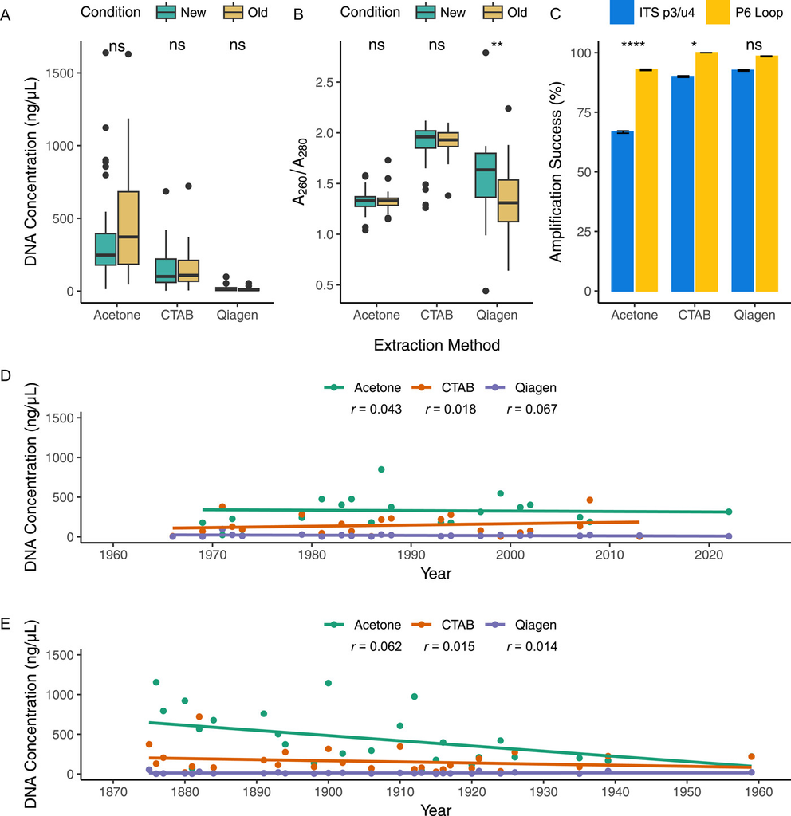

**Figure 1**

Comparison of DNA extraction methods and sample conditions. (A) Boxplot comparing DNA concentrations (ng/μL) for new and old samples using the acetone, CTAB, and Qiagen DNeasy Plant Mini Kit methods. (B) Boxplot comparing DNA quality of new and old samples from the three different protocols measured by A<sub>260</sub>/A<sub>280</sub> absorbance ratios. (C) Bar plot indicating PCR amplification success (mean ± SD) of two regions, the nuclear ITS-p3/u4 region and P6 loop of the *trnL* (UAA) chloroplast intron, using three different extraction methods for all samples. (D) Scatterplot showing the relationship between DNA concentration and collection year for new samples using the three extraction methods. (E) Scatterplot showing the relationship between DNA concentration and collection year for old samples, using the three extraction methods. The lines represent a best linear fit for the relationship between the DNA concentration and the collection year of the herbarium samples for each of the three extraction methods. *r*-values indicate Pearson correlation coefficients. Symbols indicating statistical significance for Wilcoxon signed-rank tests: ns = *P* > 0.05; * = *P* ≤ 0.05; ** = *P* ≤ 0.01; **** = *P* ≤ 0.0001.

Estimated material costs for the three DNA extraction methods tested in this study varied. Approximate cost per sample (USD) was $4.94 for the Qiagen DNeasy Plant Mini Kit, $0.94 for CTAB, and $0.23 for our acetone method. If there are hundreds or even thousands of samples that need to be analyzed, our acetone method or CTAB would be the most affordable, although the hazards of exposure to phenol should also be factored in with the CTAB method. All three methods require tissue homogenization, which has associated costs for specialized equipment, including a microcentrifuge and vortex, which were not included in the cost estimate. The CTAB and DNeasy kit protocols require a heated water or dry bath, but our improved acetone method no longer requires this. It should be noted that further costs associated with PCR amplification were also not considered, but the four different polymerases that were tested in this study do differ in cost per unit. The time taken to complete DNA extractions for 24 samples at one time varied from 1.16 h, 1.75 h, and 40 min for the DNeasy, CTAB, and acetone protocols, respectively.

## CONCLUSIONS

The many DNA extraction protocols vary in cost and efficiency, and ideal extraction techniques should optimize yield, minimize degradation, and be affordable and efficient in terms of overall processing time, cost, and labor. Our modified acetone-based DNA extraction protocol was shown to provide a rapid, inexpensive option for obtaining high yields of good-quality DNA from herbarium samples of diverse taxa and varying condition suitable for downstream PCR applications under optimal reaction conditions. Although the quality of DNA may generally be better using CTAB or the Qiagen commercial kit, especially for longer DNA fragments, our method should be considered as a first strategy for extraction from herbarium and fresh tissue based on the speed, cost, simplicity, and small amount of starting tissue required.

## AUTHOR CONTRIBUTIONS

F.E.G., Y.G., and H.T.S. planned and designed the research; H.T.S. supplied and prepared samples; M.R.P., F.E.G., and H.T.S. wrote the first draft of the manuscript. All authors approved the final version of the manuscript.

## ACKNOWLEDGMENTS

The authors would like to thank Joseph Hughes (U.S. National Arboretum) for collecting the fresh tissue samples used in this study and the reviewers who helped improve this manuscript.

## APPENDIX 1: Collection information for herbarium and fresh samples used in this study. For all samples, a newer and older herbarium sheet was used, as well as fresh tissue as a control for a subset of samples. All herbarium specimens are located at the U.S. National Arboretum Herbarium (NA), Washington, D.C., USA; fresh tissue is from living accessions at the U.S. National Arboretum, Washington, D.C., USA.

| Taxon | Family | New herbarium specimen<sup>a</sup> Barcode no. | New herbarium specimen<sup>a</sup> Collection year | Old herbarium specimen<sup>b</sup> Barcode no. | Old herbarium specimen<sup>b</sup> Collection year | Fresh tissue<sup>c</sup> Accession no. |
| --- | --- | --- | --- | --- | --- | --- |
| *Acer rubrum* L. | Sapindaceae | NA0067818 | 2007 | NA0096726 | 1926 | NA83188-H |
| *Buxus sempervirens* L. | Buxaceae | NA0103736 | 1984 | NA0103734 | 1906 | NA8733-R |
| *Celosia argentea* L. | Amaranthaceae | NA0328312 | 1994 | NA0328318 | 1917 | NA84844-H |
| *Cephalanthus occidentalis* L. | Rubiaceae | NA0079973 | 2002 | NA0420461 | 1894 |  |
| *Chrysanthemum indicum* L. | Asteraceae | NA0042329 | 1984 | NA0607592 | 1924 |  |
| *Cycas revoluta* Thunb. | Cycadaceae | NA0014374 | 1981 | NA0014402 | 1913 |  |
| *Dioscorea japonica* Thunb. | Dioscoreaceae | NA0194155 | 1986 | NA0194167 | 1915 |  |
| *Dryopteris marginalis* (L.) A. Gray | Dryopteridaceae | NA0010993 | 2001 | NA0174693 | 1912 |  |
| *Goodyera pubescens* (Willd.) R. Br. | Orchidaceae | NA0168774 | 1966 | NA0168765 | 1884 |  |
| *Hamamelis virginiana* L. | Hamamelidaceae | NA0167699 | 1997 | NA0167617 | 1835 | NA53640-P |
| *Ilex opaca* Aiton | Aquifoliaceae | NA0253779 | 1981 | NA0253899 | 1898 | NA66327-J |
| *Juniperus occidentalis* Hook. | Cupressaceae | NA0267054 | 1971 | NA0267039 | 1882 |  |
| *Lagerstroemia indica* L. | Lythraceae | NA0022858 | 1987 | NA0674594 | 1921 |  |
| *Lilium superbum* L. | Liliaceae | NA0275222 | 1979 | NA0275215 | 1880 |  |
| *Magnolia virginiana* L. | Magnoliaceae | NA0430873 | 2001 | NA0430908 | 1924 | NA53002-H |
| *Nymphaea odorata* Aiton | Nymphaeaceae | NA0437201 | 1999 | NA0437223 | 1877 |  |
| *Osmorhiza longistylis* (Torr.) DC. | Apiaceae | NA0000891 | 1997 | NA0673050 | 1924 |  |
| *Panicum virgatum* L. | Poaceae | NA0057063 | 2008 | NA0074839 | 1884 | NA85041-H |
| *Papaver somniferum* L. | Papaveraceae | NA0464903 | 1972 | NA0453099 | 1920 |  |
| *Pinus pinceana* Gordon & Glend. | Pinaceae | NA0103576 | 1994 | NA0259085 | 1939 |  |
| *Piper barbicuspe* Trel. | Piperaceae | NA0151921 | 1973 | NA0151923 | 1935 |  |
| *Prunus angustifolia* Marshall | Rosaceae | NA0400521 | 1983 | NA0001765 | 1910 |  |
| *Quercus alba* L. | Fagaceae | NA0582326 | 2013 | NA0582387 | 1893 | NA69609-H |
| *Rhododendron calendulaceum* (Michx.) Torr. | Ericaceae | NA0033262 | 1988 | NA0024898 | 1916 |  |
| *Salix caroliniana* Michx. | Salicaceae | NA0095478 | 1993 | NA0552693 | 1902 |  |
| *Selaginella douglasii* (Hook. & Grev.) Spring | Selaginellaceae | NA0264494 | 1969 | NA0264498 | 1881 |  |
| *Solanum stoloniferum* Schltdl. | Solanaceae | NA0034220 | 1984 | NA0034693 | 1900 |  |
| *Sphaeralcea emoryi* Torr. ex A. Gray | Malvaceae | NA0230156 | 2008 | NA0230143 | 1875 |  |
| *Trifolium medium* L. | Fabaceae | NA0446872 | 1959 | NA0445585 | 1891 |  |
| *Viburnum dentatum* L. | Adoxaceae | NA0465812 | 1987 | NA0465833 | 1876 | NA85252-J |

- <sup>a</sup>New = herbarium specimen collected after 1960.
- <sup>b</sup>Old = herbarium specimen collected before 1960 and in poor condition.
- <sup>c</sup>Fresh = sample from a living accession (control).

## APPENDIX 2: Materials and methods for DNA extraction and PCR amplification.

## Reagents

- 100% acetone
- 10X TE buffer (100 mM Tris [pH 8.0], 10 mM EDTA), with 1% sodium dodecyl sulfate (SDS) (w/v) and 1% polyvinylpolypyrrolidone (PVPP) (w/v)
- Nuclease-free water
- 95% ethanol (for cleaning equipment)

## Supplies/Equipment

- Savant FastPrep FP120 (MP Biomedicals, Irvine, California, USA)
- 2-mL FastPrep tubes with cap
- 4.5-mm steel airgun shot (Daisy BBs [Daisy Outdoor Products, Rogers, Arkansas, USA])
- 5-mm-diameter cork borer
- 1.5-mL microcentrifuge tubes
- Forceps
- Vortexer
- Microcentrifuge

## Extraction protocol

- 1.

  Prepare a 2-mL FastPrep tube with a 4.5-mm steel airgun shot.
- 2.

  Use a clean cork borer to cut two 5-mm-diameter leaf disks (~3 mg each) from samples and place in FastPrep tube.
- 3.

  Process the leaf disks in the FastPrep machine by running each disk twice at speed 4.0 for 20 s.
- 4.

  Add 400 μL of 10X TE buffer containing 1% SDS and 1% PVPP.
- 5.

  Vortex briefly to mix, then centrifuge at 14,000 rpm for 5 min in a microcentrifuge.
- 6.

  Transfer 200 μL of supernatant to a 1.5-mL microtube.
- 7.

  Add 200 μL of 100% acetone. *Caution: Acetone is toxic. Please follow all recommendations from the Material Safety Data Sheet (MSDS)*.
- 8.

  Vortex briefly to mix, then centrifuge at 6000 rpm for 1 min.
- 9.

  Discard supernatant and add 100 μL of nuclease-free water.
- 10.

  Vortex briefly to mix, then centrifuge at 14,000 rpm for 1 min.
- 11.

  Save the supernatant for DNA quantitation and downstream PCR applications.

[figure not shown]

[Early View](https://bsapubs.onlinelibrary.wiley.com/toc/21680450/0/0)

Online Version of Record before inclusion in an issue

e11521

  [American Journal of Botany](https://bsapubs.onlinelibrary.wiley.com/journal/15372197)

[Download PDF](https://bsapubs.onlinelibrary.wiley.com/doi/pdf/10.1002/aps3.11521)

back